# MATH 340 - Quick Sampling Guide

Hitchman

March 01, 2023

# Data Vectors

In R, we use the `c()` command to enter a set of data. The resulting object in R is called a data vector, or vector.

To enter numerical data, we enter the numbers themselves, separated by commas witin the `c()` command. To enter categorical data we use quotes around each element in the vector.

A set of MLB teams is categorical (use quotes):

```r
t=c("SEA","OAK","HOU","TEX","LAA")
```

A set of wins for each team is numerical (no quotes):

```r
w=c(79,51,93,62,61)
```

As an aside: With the `data.frame()` command we can create a data matrix, or data frame, such as you see in a spreadsheet, to link these two vectors (a team to its wins).

```r
AL.west=data.frame(team=t,wins=w)
AL.west
```

```
##   team wins
## 1  SEA   79
## 2  OAK   51
## 3  HOU   93
## 4  TEX   62
## 5  LAA   61
```

We can **extract an element** of a vector by indicating its [position]:

```r
t[3]
```

```
## [1] "HOU"
```

Or we can specify several elements:

```r
t[2:4]
```

```
## [1] "OAK" "HOU" "TEX"
```

We can **count how many elements** in a vector that meet some criterion:

```r
sum(w<70)
```

```
## [1] 3
```

We can find **which elements** (by position) in a vector meet some criterion:

```r
which(w<70)
```

```
## [1] 2 4 5
```

**Comparing two vectors**: The following code counts the number of positions in which two vectors of the same length agree.

```r
sum(c(3,2,6,4,1,5)==c(2,3,1,4,6,5)) # these vectors agree in two positions (the 4th and 6th)
```

```
## [1] 2
```

## Example: Hank Aaron

Hank Aaron’s homeruns by season:

13, 27, 26, 44, 30, 39, 40, 34, 45, 44, 24, 32, 44, 39, 29, 44, 38, 47, 34, 40, 20, 12, 10

We enter this numerical data set in R as a vector called *hank* with this code. Recall, we separate the elements by commas within the `c()` command.

```r
hank=c(13,27,26,44,30,39,40,34,45,44,24,32,44,39,29,44,38,47,34,40,20,12,10)
```

With *hank* loaded into your session, you can analyze it by name. For instance, we can find the

- mean of these data with `mean(hank)`
- the max of these data (best HR season) with `max(hank)`
- the standard deviation of these data with `sd(hank)`,
- the length of the vector (number of seasons) with `length(hank)`
- etc…

What does the `diff()` command do?

```r
diff(hank)
```

```
##  [1]  14  -1  18 -14   9   1  -6  11  -1 -20   8  12  -5 -10  15  -6   9 -13   6
## [20] -20  -8  -2
```

(Notice `length(diff(hank))` = 22, whereas `length(hank)` = 23.)

How about the `cumsum()` command?

```r
cumsum(hank)
```

```
##  [1]  13  40  66 110 140 179 219 253 298 342 366 398 442 481 510 554 592 639 673
## [20] 713 733 745 755
```

## Special vectors

1. **The integers 1 to n** can be entered by typing `1:n` (for a particular $n$), or `c(1:n)`. For instance, we could define a 20 sided die by entering

```r
die=c(1:20)
```

2. Using `rep()`. The `rep()` command lets us build a vector that has lots of elements repeated. Let’s say we want a bag of skittles, and we want 40 red, 30 orange, 25 yellow, 60 green, and 20 purple. The `rep()` command works like this: first enter the distinct items (as a vector with the `c()` command!), then enter how many times each is repeated (as a vector!):

```r
skittles=rep(c("red","orange","yellow","green","purple"),c(40,30,25,60,20))
```

3. Using `seq()`. The `seq()` command lets us enter an arithmetic progression by entering (first, last, increment).

```r
seq(0,1,by=.1)
```

```
##  [1] 0.0 0.1 0.2 0.3 0.4 0.5 0.6 0.7 0.8 0.9 1.0
```

## Recursively defined vectors

**Motivation** We may conduct by iteration (with a `for` loop, perhaps) many, many trials of some experiment. We can store the outcomes in a vector (called `results`, perhaps), one outcome at a time within the iteration.

The key idea is that `c()` allows you to concatenate vectors:

```r
u=c(1,2,3)
v=c(4,5,6)
c(u,v)
```

```
## [1] 1 2 3 4 5 6
```

Or add an element to the end of a vector

```r
A = c("Will","Lucas","Mike","Dustin")
c(A,"Eleven")
```

```
## [1] "Will"   "Lucas"  "Mike"   "Dustin" "Eleven"
```

**Example** Roll three 6 sided dice and add their values. Repeat 1000 times to get a sense of which sums are most likely.

We can start with an empty vector called `results` in which we will store the outcomes for each of our 1000 rolls.

```r
results = c()
```

The code below creates a command called `roll.sum()`. This function rolls **three** 6-sided dice and returns the sum of the values (more on the `sample()` command used to roll the dice below).

```r
roll.sum <- function(){
  return(sample(1:6,1)+sample(1:6,1)+sample(1:6,1))
}
```

Now, back to generating a `results` vector recursively. In the end we roll the dice 1000 times, and store the 1000 sums in the vector `results`.

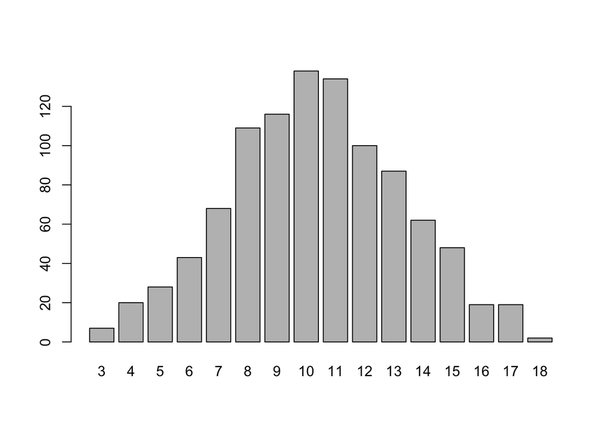

```r
for (i in 1:1000){
  s=roll.sum() # roll the dice, call the sum s
  results = c(results,s) #this adds to the end of the results vector the value s.
}
barplot(table(results)) # frequency plot - which outcomes occur and how often they occur
```

# Sampling

## Sampling from a named vector.

We use the `sample(x,...)` command to sample from vector `x`.

We can draw a random sample from *hank*. Why? Perhaps we want to hypothesize about this: If we pick two seasons from his career at random, what is the probability that he hit a combined total of at least 50 HR in those two seasons?

```r
sample(hank,2,replace=FALSE)
```

```
## [1] 26 24
```

Here’s another example. Let’s grab 20 skittles at random from the bag we created above (and denoted `skittles`), and count how many orange ones we get:

```r
grab=sample(skittles,20,replace=FALSE)
table(grab)
```

```
## grab
##  green orange purple    red yellow
##      4      9      3      3      1
```

The `table()` command counts how many of each color :).

We could have gone straight to the orange count with

```r
sum(grab=="orange")
```

```
## [1] 9
```

**Summary of R methods used**

| command | description |
| --- | --- |
| `c()` | creates a data vector |
| `sample.int()` | generating a random sample from a set $\{1,2,\ldots,n\}$ of integers |
| `sample(x,...)` | generating a random sample from a vector `x` |
| `rep()` | replicates the values in a vector a specified number of times |
| `table()` | returns the frequency of each unique value of the data |
| `sum()` | sums the values in a vector, or the number of elements in a vector that meet some condition. |

## Integer Sampling

The `sample.int()` command will generate samples from the set $\{1, ..., n\}$ for specified $n$.

### without replacement

> **Example:**  
> Pick 4 students at random from a class of 9 to race around Taylor Hall. (Assumes we have numbered the students 1-9).

```r
sample.int(9,4)
```

```
## [1] 4 2 9 6
```

### with replacement

> **Example:**  
> On twelve consecutive days, ask one student at random, in a class of size 9, to write a solution on the board.

```r
sample.int(9,12,replace=TRUE)
```

```
##  [1] 2 1 7 4 5 4 3 9 7 5 9 9
```

### with custom probabilities

> **Example:**  
> Roll a weighted 6 sided die with the following probability distribution 100 times and summarize the results.

| $x$ | 1 | 2 | 3 | 4 | 5 | 6 |
| --- | --- | --- | --- | --- | --- | --- |
| $p(x)$ | .2 | .1 | .05 | .4 | .1 | .15 |

```r
table(sample.int(6,100,replace=TRUE,p=c(.2,.1,.05,.4,.1,.15)))
```

```
##
##  1  2  3  4  5  6
## 17  8  3 44  8 20
```

**Example** Here’s a vector (of all baseball teams in the American League):

```r
AL=c("SEA","HOU","LAA","OAK","TEX","BAL","NYY","BOS","TOR","TB","CHW","MIN","CLE","KC","DET")
```

**Sampling with replacement**

```r
sample(AL,6,replace=TRUE)
```

```
## [1] "HOU" "TB"  "TB"  "CHW" "BAL" "BAL"
```

**Sampling without replacement**

```r
sample(AL,6)
```

```
## [1] "HOU" "LAA" "OAK" "MIN" "DET" "BOS"
```

# Sampling with custom probabilities

> **Example**: 8% of a population is left-handed. Draw a random sample of 45 people from the population and record the number of lefties.

One approach: build a large population with these features and then draw 45 people from it without replacement.

```r
pop=rep(c("L","R"),c(800,9200))
table(sample(pop,45))
```

```
##
##  L  R
##  3 42
```

A second approach: sample with replacement 45 times from a “two-sided” die with customized probabilities

```r
die=c("L","R")
table(sample(die,45,replace=TRUE,prob=c(.08,.92)))
```

```
##
##  L  R
##  2 43
```

A third approach: Use a binomial distribution (later)

# Repeated Sampling

Let’s say we have a huge urn full of orange and blue marbles, and 42% of them are orange. If we draw 50 marbles at random from the urn, approximate the **sampling distribution** for the number of orange marbles drawn? That is, what sorts of orange marble counts should we expect, and how often should we expect these counts?

*Repeated sampling* can estimate this sampling distribution. Here are two methods for achieving repeated sampling in R.

## Using a `for` loop

The code below creates a vector called *o.counts* that, eventually, after the for loop has completed, has 2000 entries. Each entry in this vector gives the number of orange marbles drawn from the urn from a random sample of 50 marbles.

```r
o.counts=c() #a vector for storing the results of each trial
for (i in 1:2000){
  r=sum(sample(c("orange","blue"),50,replace=TRUE,prob=c(.42,.58))=="orange")
  o.counts=c(o.counts,r)
}
```

We can display the results of this repeated sampling with a histogram to get a sense of what is typical in terms of number of orange marbles drawn:

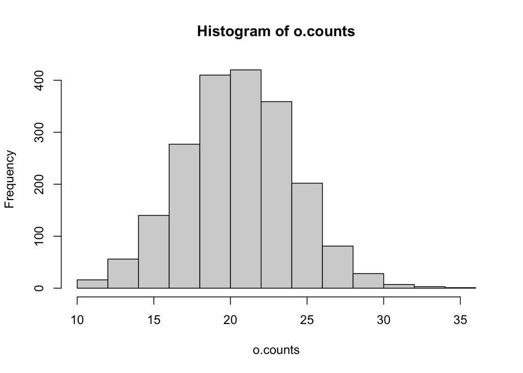

```r
hist(o.counts)
```

## Using `replicate()`

The `replicate()` command essentially does the same thing.

```r
o.counts=replicate(2000,sum(sample(c("orange","blue"),50,replace=TRUE,prob=c(.42,.58))=="orange"))
```

Again, the vector `o.counts` stores the number of orange marbles drawn in each of the trials. Descriptive statistics on this vector help us answer the question of what sorts of orange counts to expect.

| statistic | command | result |
| --- | --- | --- |
| mean | `mean(o.counts)` | 20.9895 |
| standard deviation | `sd(o.counts)` | 3.5417032 |
| five number summary | `fivenum(o.counts)` | 11, 19, 21, 23, 32 |

We can also summarize the *frequency* with which each value of o.counts occurs with the `table()` method, and visualize this frequency table with a `barplot`:

```r
table(o.counts)
```

```
## o.counts
##  11  12  13  14  15  16  17  18  19  20  21  22  23  24  25  26  27  28  29  30
##   4  13  12  38  52  73 126 158 191 249 238 197 182 124 123  89  67  33  13   6
##  31  32
##   9   3
```

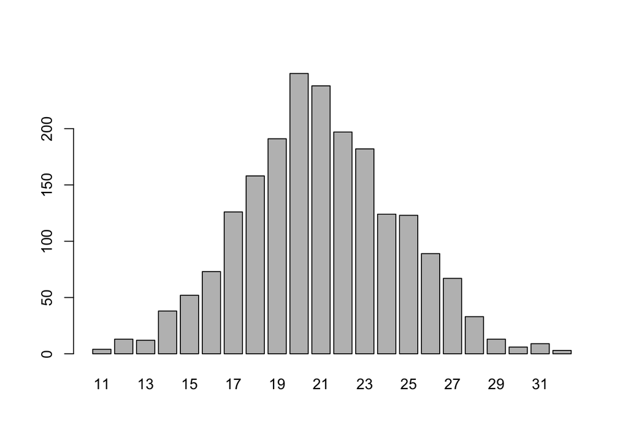

```r
barplot(table(o.counts))
```